# Hazard in Firebaugh

Samantha Liu

2020-12-22

```r
acs5_vars <- readRDS("acs5_vars.rds")

get_census_bg <- function(group) {
  getCensus(
    name = "acs/acs5",
    vintage = 2019,
    region = "block group:*",
    regionin = "state:06+county:019",
    vars = paste0("group(", group, ")")
  ) %>%
    mutate(block_group = paste0(state, county, tract, block_group)) %>%
    select(
      !c(GEO_ID, state, county, tract, NAME) &
        !ends_with(c("EA", "MA", "M"))
    ) %>%
    pivot_longer(
      ends_with("E"),
      names_to = "variable",
      values_to = "estimate"
    ) %>%
    left_join(
      acs5_vars %>%
        select(name, label),
      by = c("variable" = "name")
    ) %>%
    select(-variable) %>%
    filter(block_group == "060190084011")
}

get_census_tract <- function(group) {
  getCensus(
    name = "acs/acs5",
    vintage = 2019,
    region = "tract:*",
    regionin = "state:06+county:019",
    vars = paste0("group(", group, ")")
  ) %>%
  mutate(tract = paste0(state, county, tract)) %>%
  select(
    !c(GEO_ID, state, county, NAME) &
      !ends_with(c("EA", "MA", "M"))
  ) %>%
  pivot_longer(
    ends_with("E"),
    names_to = "variable",
    values_to = "estimate"
  ) %>%
  left_join(
    acs5_vars %>%
      select(name, label),
    by = c("variable" = "name")
  ) %>%
  select(-variable) %>%
    filter(tract == "06019008401")
}
```

Building Data obtained from [Geofabrik](http://download.geofabrik.de/) makes many components of OSM available for easy download. After clicking a few levels down, you can find a [NorCal](http://download.geofabrik.de/north-america/us/california/norcal.html) page with a 700MB file for download with [these attributes](http://download.geofabrik.de/osm-data-in-gis-formats-free.pdf). Another option is Microsoft’s AI-generated [building footprints](https://github.com/Microsoft/USBuildingFootprints), which may be more or less accurate than OSM in different places. Their GitHub repo includes links to download the files as GeoJSONs by state, but California is massive, so a nice option is to use [county-level disaggregations](https://drive.google.com/drive/folders/1-XGvS25tQKKQ3HTqWjAfLJ4PaeXJ9yyY) done by [Patty Frontiera](https://dlab.berkeley.edu/blog/leave-only-footprints) at Berkeley.

## Hazard Data

Data Sources: [Cal Adapt](https://cal-adapt.org/)

Row numbers that result in a lexicon error: 46, 62, 108, 109, 134, 220

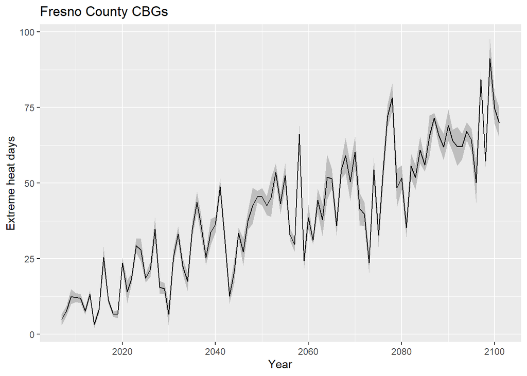

```r
exheat_full <- readRDS("exheat_full.rds")

exheat_full %>%
  group_by(year) %>%
  summarize(
    exheat_mean = mean(exheat, na.rm = T),
    exheat_sd = sd(exheat, na.rm = T)
  ) %>%
  ggplot(
    aes(
      x = year
    )
  ) +
  geom_ribbon(
    aes(
      ymin = exheat_mean - exheat_sd,
      ymax = exheat_mean + exheat_sd
    ),
    fill = "grey"
  ) +
  geom_line(
    aes(
      y = exheat_mean
    )
  ) +
  labs(
    x = "Year",
    y = "Extreme heat days",
    title = "Fresno County CBGs"
  )
```

```r
exheat_2020s <-
  exheat_full %>%
  filter(year >= "2020-01-01" & year <= "2029-12-31") %>%
  group_by(cbg) %>%
  summarize(exheat = mean(exheat, na.rm = T)) %>%
  left_join(fresno_cbgs %>% dplyr::select(cbg = GEOID)) %>%
  st_as_sf()

heat_pal <- colorNumeric(
  palette = "Reds",
  domain = exheat_2020s$exheat
)

leaflet() %>%
  addProviderTiles(providers$CartoDB.Positron) %>%
  addPolygons(
    data = exheat_2020s,
    fillColor = ~heat_pal(exheat),
    fillOpacity = 0.5,
    color = "white",
    weight = 0.5,
    label = ~paste0(cbg, ": ", exheat, " extreme heat days per year over the next decade"),
    highlightOptions = highlightOptions(
      weight = 2,
      opacity = 1
    )
  ) %>%
  addLegend(
    data = exheat_2020s,
    pal = heat_pal,
    values = ~exheat,
    title = "Extreme heat days<br>per year over<br>next decade"
  )
```

[interactive chart not shown]

## Exposure Data

Equity Analys on Heat Exposure - Assumes extreme heat affects everyone in a given census tract the same way

```r
bg_income <-
  getCensus(
    name = "acs/acs5",
    vintage = 2019,
    region = "block group:*",
    regionin = "state:06+county:019",
    vars = "group(B19001)"
  ) %>%
  mutate(cbg = paste0(state, county, tract, block_group)) %>%
  select(
    !c(GEO_ID, state, county, tract, block_group, NAME) &
      !ends_with(c("EA", "MA", "M"))
  ) %>%
  pivot_longer(
    ends_with("E"),
    names_to = "variable",
    values_to = "estimate"
  ) %>%
  left_join(
    acs5_vars %>%
      select(name, label),
    by = c("variable" = "name")
  ) %>%
  select(-variable) %>%
  separate(
    label,
    into = c(NA,NA,"income"),
    sep = "!!"
  ) %>%
  filter(!is.na(income)) %>%
  mutate(
    income = case_when(
      income %in% c("Less than $10,000","$10,000 to $14,999","$15,000 to $19,999","$20,000 to $24,999") ~ "Less than $25,000",
      income %in% c("$25,000 to $29,999","$30,000 to $34,999","$35,000 to $39,999","$40,000 to $44,999","$45,000 to $49,999") ~ "$25,000 to $49,999",
      income %in% c("$50,000 to $59,999","$60,000 to $74,999") ~ "$50,000 to $74,999",
      TRUE ~ income
    )
  ) %>%
  group_by(cbg, income) %>%
  summarize(estimate = sum(estimate, na.rm = TRUE))
```

Extreme Heat Day buckets 250-300 should be lumped with 225-250 because of how small the total number of households they affect

```r
heat_exp_income <-
  bg_income %>%
  left_join(
    exheat_full %>%
      filter(year >= "2020-01-01" & year <= "2029-12-31") %>%
      group_by(cbg) %>%
      summarize(exheat = sum(exheat)),
    by = c("cbg")
  ) %>%
  filter(!is.na(exheat)) %>%
  mutate(
    exheat_tier =
      case_when(
        exheat < 175 ~ "150-175",
        exheat < 200 ~ "175-200",
        exheat < 225 ~ "200-225",
        # exheat < 250 ~ "225-250",
        # exheat < 275 ~ "250-275",
        TRUE ~ "225-300"
      )
  ) %>%
  group_by(income, exheat_tier) %>%
  summarize(estimate = sum(estimate, na.rm = T)) %>%
  mutate(
    income = income %>% factor(levels = rev(c("Less than $25,000", "$25,000 to $49,999", "$50,000 to $74,999", "$75,000 to $99,999", "$100,000 to $124,999", "$125,000 to $149,999", "$150,000 to $199,999", "$200,000 or more")))
  )
```

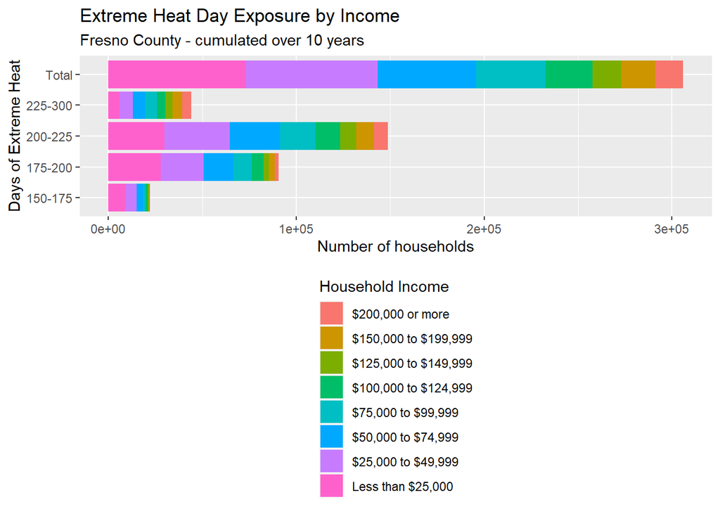

```r
heat_exp_income %>%
  rbind(
    heat_exp_income %>%
      group_by(income) %>%
      summarize(estimate = sum(estimate)) %>%
      mutate(exheat_tier = "Total")
  ) %>%
  ggplot() +
  geom_bar(
    aes(
      x = exheat_tier %>% factor(levels = c("150-175", "175-200", "200-225", "225-300", "Total")),
      y = estimate,
      fill = income
    ),
    stat = "identity",
    position = "stack"
  ) +
  labs(
    x = "Days of Extreme Heat",
    y = "Number of households",
    title = "Extreme Heat Day Exposure by Income",
    subtitle = "Fresno County - cumulated over 10 years",
    fill = "Household Income"
  ) +
  coord_flip() +
  theme(
    legend.position = "bottom",
    legend.direction = "vertical"
  )
```

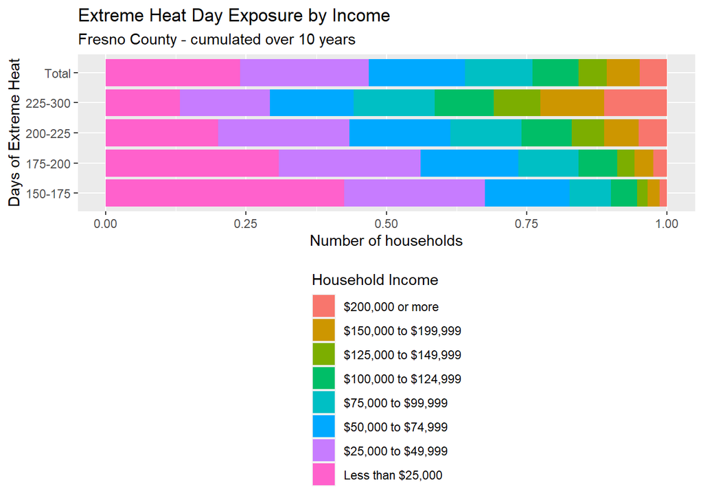

```r
heat_exp_income %>%
  rbind(
    heat_exp_income %>%
      group_by(income) %>%
      summarize(estimate = sum(estimate)) %>%
      mutate(exheat_tier = "Total")
  ) %>%
  ggplot() +
  geom_bar(
    aes(
      x = exheat_tier %>% factor(levels = c("150-175", "175-200", "200-225", "225-300", "Total")),
      y = estimate,
      fill = income
    ),
    stat = "identity",
    position = "fill"
  ) +
  labs(
    x = "Days of Extreme Heat",
    y = "Number of households",
    title = "Extreme Heat Day Exposure by Income",
    subtitle = "Fresno County - cumulated over 10 years",
    fill = "Household Income"
  ) +
  coord_flip() +
  theme(
    legend.position = "bottom",
    legend.direction = "vertical"
  )
```

## ACS Demographics

Total number of households recorded in Firebaugh according to ACS 2015-2019: 2321 Total number of occupied households recorded in Firebaugh according to ACS 2015-2019: 844 Total number recorded given by FHA: 2033

```r
# housing costs as % of income
fb_housing_costs <-
  get_census_tract("B25106") %>%
  separate(
    label,
    into = c(NA, NA, "tenure", "income", "% of income"),
    sep = "!!"
  ) %>%
  filter(!is.na(`% of income`))

# HH Income - cbg level
fb_hhincome <-
  get_census_bg("B19001") %>%
  separate(
    label,
    into = c(NA, NA, "income"),
    sep = "!!"
  ) %>%
  filter(!is.na(income))

# aggregate vehicles available - cbg level
fb_vehicles <-
  get_census_bg("B25046") %>%
  separate(
    label,
    into = c(NA, NA, "tenure"),
    sep = "!!"
  ) %>%
  filter(!is.na(`tenure`)) %>%
  mutate(
    hh = c(342, 502), # obtained from fb_beds
    veh_per_hh = estimate / hh
  )

# bedrooms - cbg level
fb_beds <-
  get_census_bg("B25042") %>%
  separate(
    label,
    into = c(NA, NA, "tenure", "beds"),
    sep = "!!"
  ) %>%
  filter(!is.na(beds))

# units per structure - cbg level
fb_units <-
  get_census_bg("B25032") %>%
  separate(
    label,
    into = c(NA, NA, "tenure", "units"),
    sep = "!!"
  ) %>%
  filter(!is.na(units))

# hhsize by units in structure
fb_units_hhsize <-
  get_census_tract("B25124") %>%
  separate(
    label,
    into = c(NA, NA, "tenure", "HH Size", "units"),
    sep = "!!"
  ) %>%
  filter(!is.na(units))

# total pop by units in structure - cbg level
fb_units_pop <-
  get_census_bg("B25033") %>%
  separate(
    label,
    into = c(NA, NA, "tenure", "units"),
    sep = "!!"
  ) %>%
  filter(!is.na(units))

# heating fuel
fb_fuel <-
  get_census_tract("B25117") %>%
  separate(
    label,
    into = c(NA, NA, "tenure", "fuel"),
    sep = "!!"
  ) %>%
  filter(!is.na(fuel))

# computer and internet access by educational attainment - cbg level
fb_internet_education <-
  get_census_bg("B28006") %>%
  separate(
    label,
    into = c(NA, NA, "education", "computer", "internet"),
    sep = "!!"
  ) %>%
  mutate(
    internet = ifelse(computer == "No computer", "No computer", internet)
  ) %>%
  filter(!is.na(internet))

# internet access by income - cbg level
fb_internet_income <-
  get_census_bg("B28004") %>%
  separate(
    label,
    into = c(NA, NA, "income", "internet"),
    sep = "!!"
  ) %>%
  filter(!is.na(internet))
```

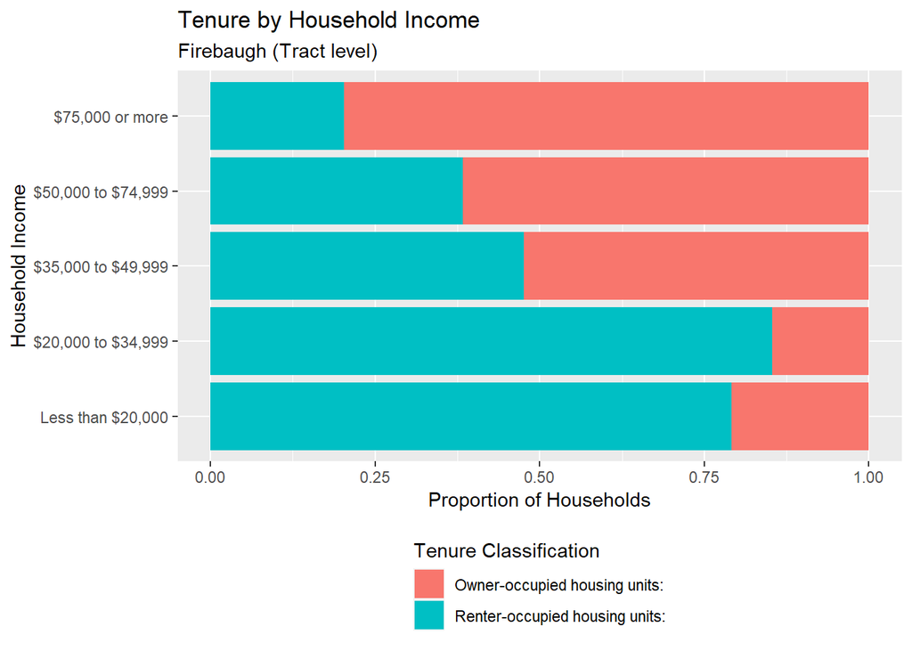

```r
fb_housing_costs %>%
  group_by(tract, tenure, income) %>%
  summarize(estimate = sum(estimate, na.rm = TRUE)) %>%
  mutate(
    income =
      income %>%
      substr(1, nchar(.) - 1) %>%
      factor(
        levels =
          c("Less than $20,000", "$20,000 to $34,999", "$35,000 to $49,999", "$50,000 to $74,999", "$75,000 or more")
      )
  ) %>%
  ggplot() +
  geom_bar(
    aes(
      x = income,
      y = estimate,
      fill = tenure
    ),
    stat = "identity",
    position = "fill"
  ) +
  labs(
    x = "Household Income",
    y = "Proportion of Households",
    title = "Tenure by Household Income",
    subtitle = "Firebaugh (Tract level)",
    fill = "Tenure Classification"
  ) +
  coord_flip() +
  theme(
    legend.position = "bottom",
    legend.direction = "vertical"
  )
```

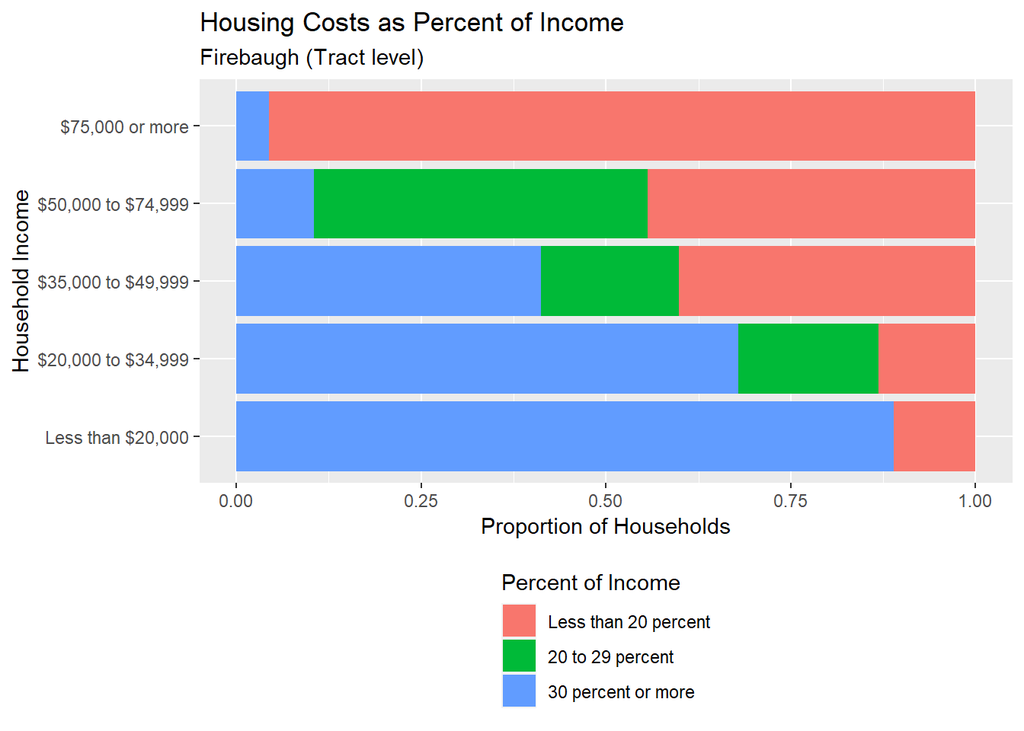

```r
fb_housing_costs %>%
  group_by(tract, `% of income`, income) %>%
  summarize(estimate = sum(estimate, na.rm = TRUE)) %>%
  mutate(
    income =
      income %>%
      substr(1, nchar(.) - 1) %>%
      factor(
        levels =
          c("Less than $20,000", "$20,000 to $34,999", "$35,000 to $49,999", "$50,000 to $74,999", "$75,000 or more")
      ),
    `% of income` = `% of income` %>% factor(levels = c("Less than 20 percent", "20 to 29 percent", "30 percent or more"))
  ) %>%
  ggplot() +
  geom_bar(
    aes(
      x = income,
      y = estimate,
      fill = `% of income`
    ),
    stat = "identity",
    position = "fill"
  ) +
  labs(
    x = "Household Income",
    y = "Proportion of Households",
    title = "Housing Costs as Percent of Income",
    subtitle = "Firebaugh (Tract level)",
    fill = "Percent of Income"
  ) +
  coord_flip() +
  theme(
    legend.position = "bottom",
    legend.direction = "vertical"
  )
```

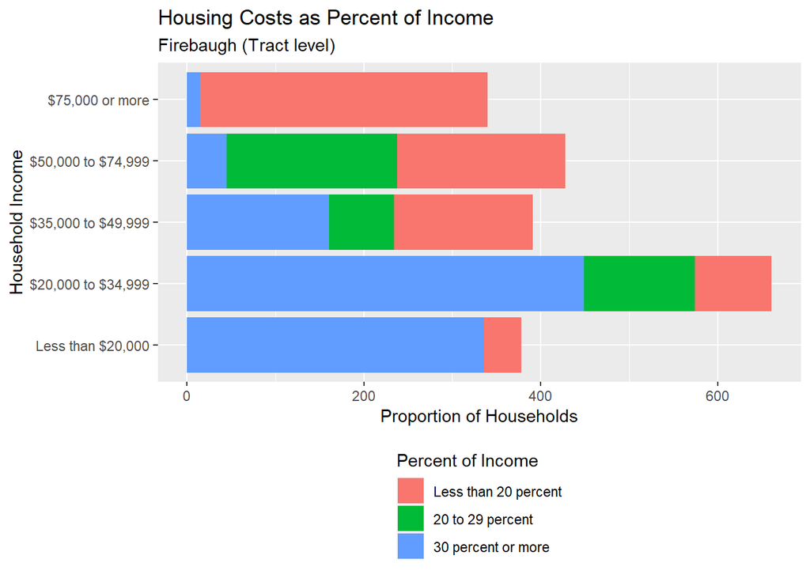

```r
fb_housing_costs %>%
  group_by(tract, `% of income`, income) %>%
  summarize(estimate = sum(estimate, na.rm = TRUE)) %>%
  mutate(
    income =
      income %>%
      substr(1, nchar(.) - 1) %>%
      factor(
        levels =
          c("Less than $20,000", "$20,000 to $34,999", "$35,000 to $49,999", "$50,000 to $74,999", "$75,000 or more")
      ),
    `% of income` = `% of income` %>% factor(levels = c("Less than 20 percent", "20 to 29 percent", "30 percent or more"))
  ) %>%
  ggplot() +
  geom_bar(
    aes(
      x = income,
      y = estimate,
      fill = `% of income`
    ),
    stat = "identity",
    position = "stack"
  ) +
  labs(
    x = "Household Income",
    y = "Proportion of Households",
    title = "Housing Costs as Percent of Income",
    subtitle = "Firebaugh (Tract level)",
    fill = "Percent of Income"
  ) +
  coord_flip() +
  theme(
    legend.position = "bottom",
    legend.direction = "vertical"
  )
```

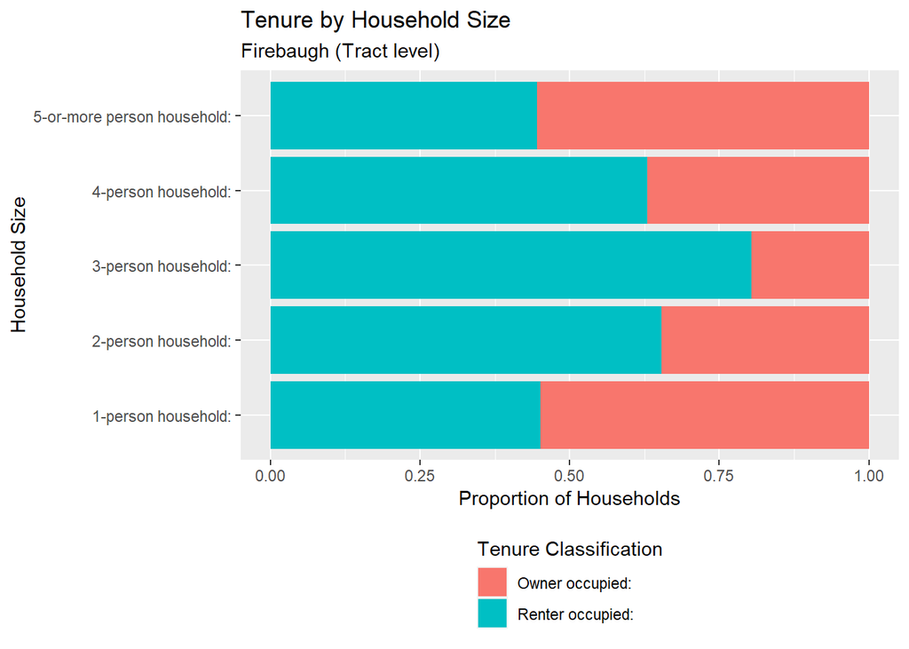

```r
fb_units_hhsize %>%
  group_by(tract, tenure, `HH Size`) %>%
  summarize(estimate = sum(estimate, na.rm = TRUE)) %>%
  ggplot() +
  geom_bar(
    aes(
      x = `HH Size`,
      y = estimate,
      fill = tenure
    ),
    stat = "identity",
    position = "fill"
  ) +
  labs(
    x = "Household Size",
    y = "Proportion of Households",
    title = "Tenure by Household Size",
    subtitle = "Firebaugh (Tract level)",
    fill = "Tenure Classification"
  ) +
  coord_flip() +
  theme(
    legend.position = "bottom",
    legend.direction = "vertical"
  )
```

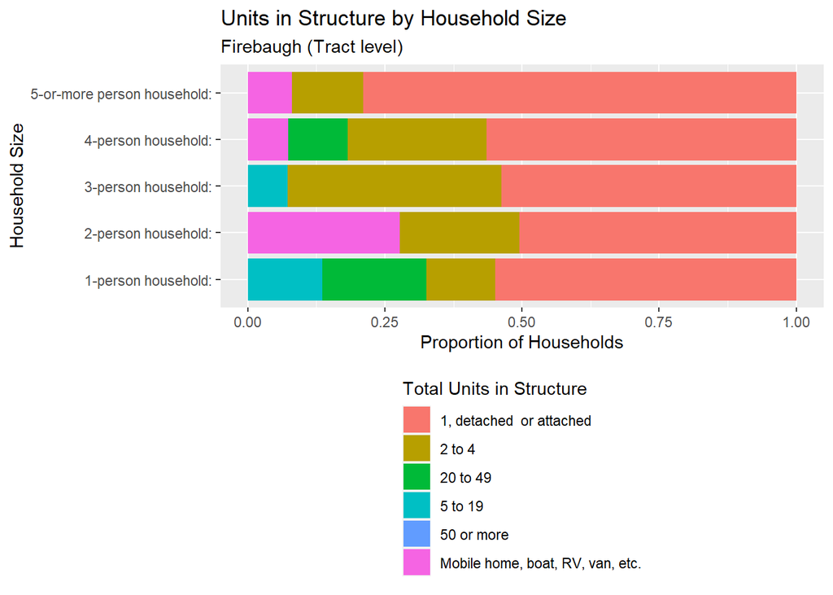

```r
fb_units_hhsize %>%
  group_by(tract, units, `HH Size`) %>%
  summarize(estimate = sum(estimate, na.rm = TRUE)) %>%
  mutate(units = ifelse(units == "1, detached  or attached:", "1, detached  or attached", units)) %>%
  ggplot() +
  geom_bar(
    aes(
      x = `HH Size`,
      y = estimate,
      fill = units
    ),
    stat = "identity",
    position = "fill"
  ) +
  labs(
    x = "Household Size",
    y = "Proportion of Households",
    title = "Units in Structure by Household Size",
    subtitle = "Firebaugh (Tract level)",
    fill = "Total Units in Structure"
  ) +
  coord_flip() +
  theme(
    legend.position = "bottom",
    legend.direction = "vertical"
  )
```

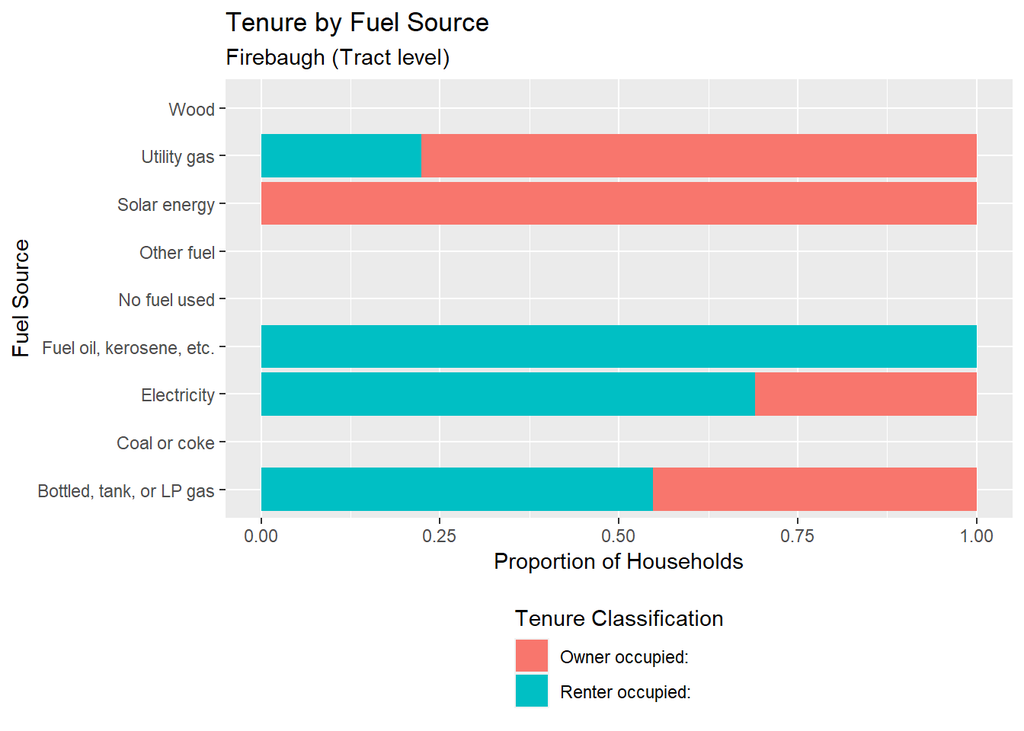

```r
fb_fuel %>%
  group_by(tract, tenure, fuel) %>%
  summarize(estimate = sum(estimate, na.rm = TRUE)) %>%
  ggplot() +
  geom_bar(
    aes(
      x = fuel,
      y = estimate,
      fill = tenure
    ),
    stat = "identity",
    position = "fill"
  ) +
  labs(
    x = "Fuel Source",
    y = "Proportion of Households",
    title = "Tenure by Fuel Source",
    subtitle = "Firebaugh (Tract level)",
    fill = "Tenure Classification"
  ) +
  coord_flip() +
  theme(
    legend.position = "bottom",
    legend.direction = "vertical"
  )
```

Median Income Bracket for the neighborhood is $30,000 - $34,999 Approximate number of vehicles per household for owned-homes: 2.62 Approximate number of vehicles per household for rented-homes: 0.92

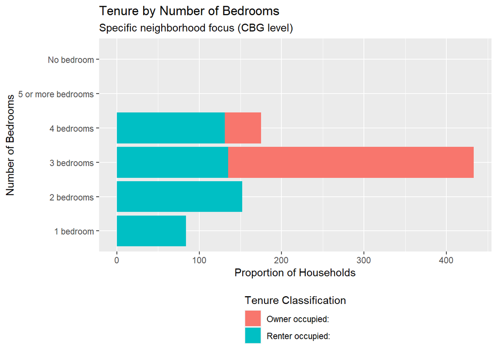

```r
fb_beds %>%
  group_by(block_group, tenure, beds) %>%
  summarize(estimate = sum(estimate, na.rm = TRUE)) %>%
  ggplot() +
  geom_bar(
    aes(
      x = beds,
      y = estimate,
      fill = tenure
    ),
    stat = "identity",
    position = "stack"
  ) +
  labs(
    x = "Number of Bedrooms",
    y = "Proportion of Households",
    title = "Tenure by Number of Bedrooms",
    subtitle = "Specific neighborhood focus (CBG level)",
    fill = "Tenure Classification"
  ) +
  coord_flip() +
  theme(
    legend.position = "bottom",
    legend.direction = "vertical"
  )
```

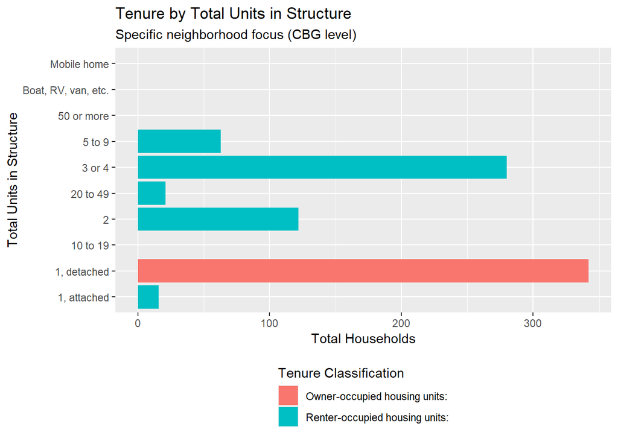

```r
fb_units %>%
  group_by(block_group, tenure, units) %>%
  summarize(estimate = sum(estimate, na.rm = TRUE)) %>%
  ggplot() +
  geom_bar(
    aes(
      x = units,
      y = estimate,
      fill = tenure
    ),
    stat = "identity",
    position = "stack"
  ) +
  labs(
    x = "Total Units in Structure",
    y = "Total Households",
    title = "Tenure by Total Units in Structure",
    subtitle = "Specific neighborhood focus (CBG level)",
    fill = "Tenure Classification"
  ) +
  coord_flip() +
  theme(
    legend.position = "bottom",
    legend.direction = "vertical"
  )
```

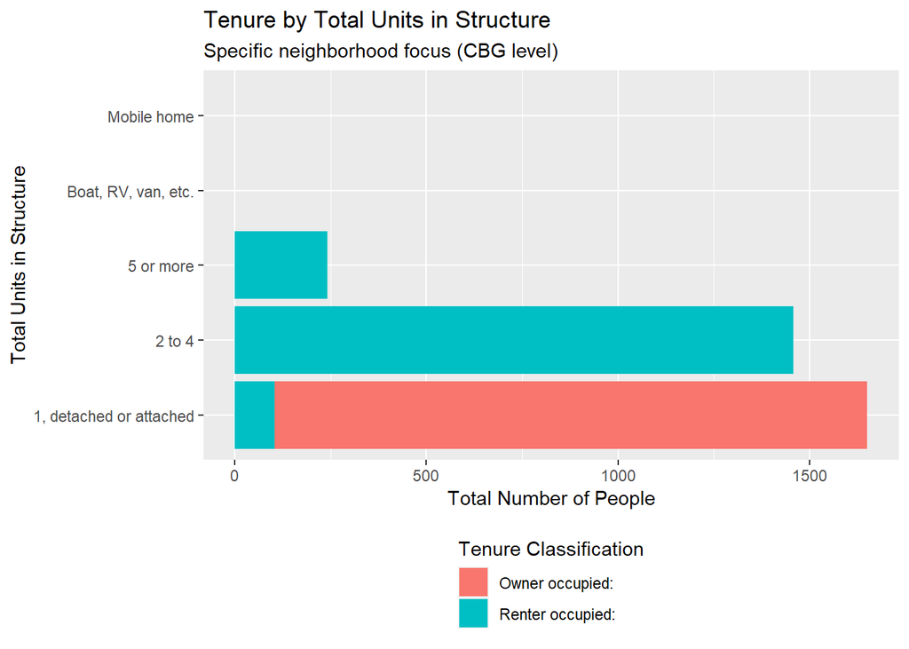

```r
fb_units_pop %>%
  group_by(block_group, tenure, units) %>%
  summarize(estimate = sum(estimate, na.rm = TRUE)) %>%
  ggplot() +
  geom_bar(
    aes(
      x = units,
      y = estimate,
      fill = tenure
    ),
    stat = "identity",
    position = "stack"
  ) +
  labs(
    x = "Total Units in Structure",
    y = "Total Number of People",
    title = "Tenure by Total Units in Structure",
    subtitle = "Specific neighborhood focus (CBG level)",
    fill = "Tenure Classification"
  ) +
  coord_flip() +
  theme(
    legend.position = "bottom",
    legend.direction = "vertical"
  )
```

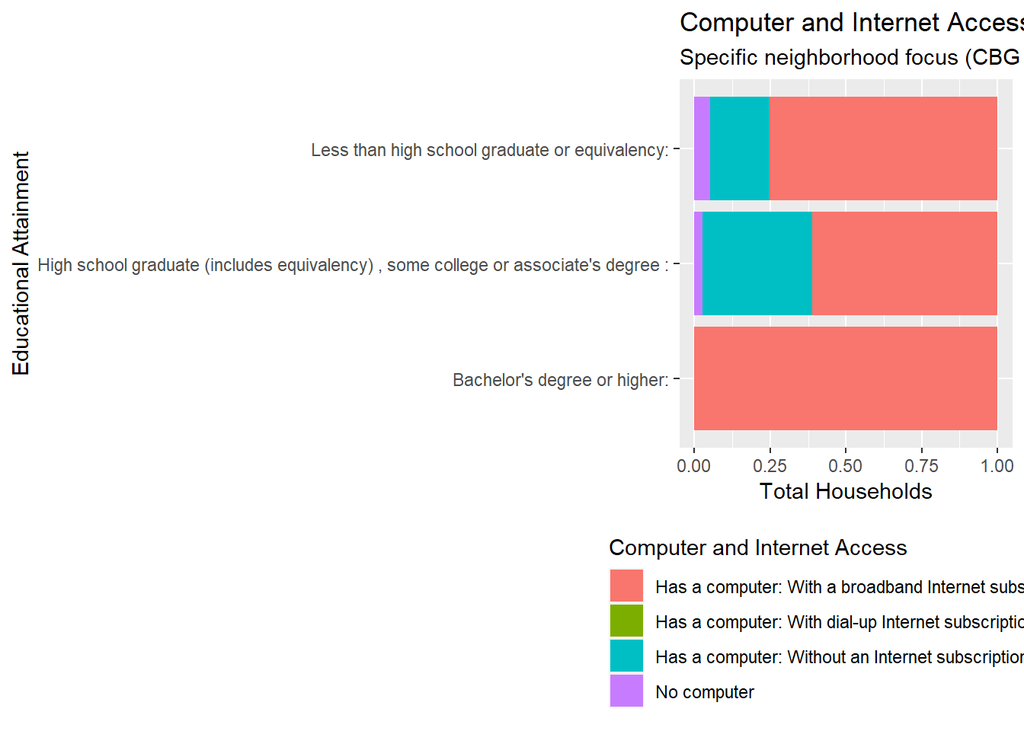

```r
fb_internet_education %>%
  mutate(
    internet = ifelse(internet == "No computer", "", internet),
    comp_int = paste(computer, internet)
  ) %>%
  ggplot() +
  geom_bar(
    aes(
      x = education,
      y = estimate,
      fill = comp_int
    ),
    stat = "identity",
    position = "fill"
  ) +
  labs(
    x = "Educational Attainment",
    y = "Total Households",
    title = "Computer and Internet Access by Educational Attainment",
    subtitle = "Specific neighborhood focus (CBG level)",
    fill = "Computer and Internet Access"
  ) +
  coord_flip() +
  theme(
    legend.position = "bottom",
    legend.direction = "vertical"
  )
```

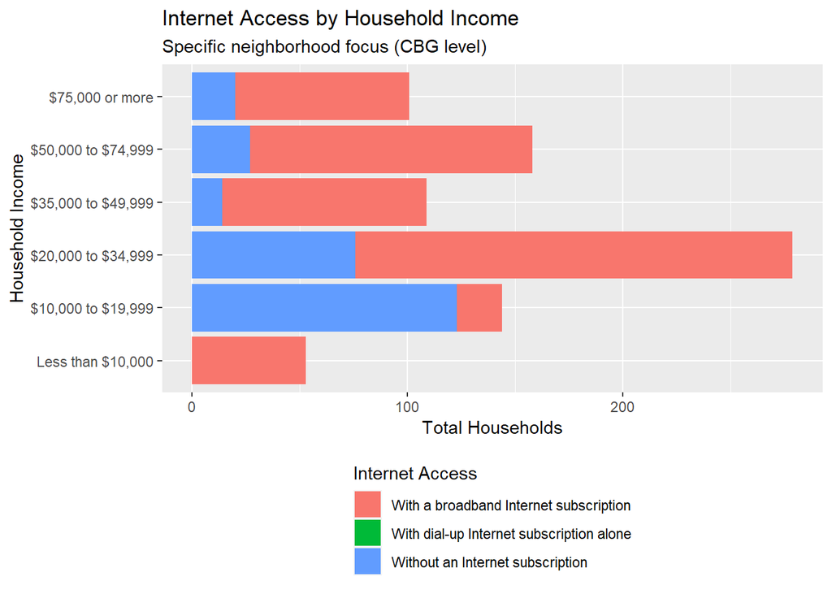

```r
fb_internet_income %>%
  mutate(
    income =
      income %>%
      substr(1, nchar(.) - 1) %>%
      factor(
        levels =
          c("Less than $10,000", "$10,000 to $19,999","$20,000 to $34,999", "$35,000 to $49,999", "$50,000 to $74,999", "$75,000 or more")
      )
  ) %>%
  ggplot() +
  geom_bar(
    aes(
      x = income,
      y = estimate,
      fill = internet
    ),
    stat = "identity",
    position = "stack"
  ) +
  labs(
    x = "Household Income",
    y = "Total Households",
    title = "Internet Access by Household Income",
    subtitle = "Specific neighborhood focus (CBG level)",
    fill = "Internet Access"
  ) +
  coord_flip() +
  theme(
    legend.position = "bottom",
    legend.direction = "vertical"
  )
```

## Land-Use

```r
leaflet() %>%
  # addTiles(group = "OSM Base Map") %>%
  addProviderTiles(providers$CartoDB.Positron) %>%
  addPolygons(
    data = fb_parcels,
    color = "green",
    fillOpacity = 0.5,
    weight = 1,
    label = ~APN
  ) %>%
  addPolygons(
    data = fb_osm_bldg,
    color = "#e851a2",
    fillOpacity = 0.5,
    weight = 1,
    label = ~ID
  )
```

[interactive chart not shown]

```r
projection <- "+proj=utm +zone=10 +ellps=GRS80 +datum=NAD83 +units=ft +no_defs"

bldg_osm <-
  fb_osm_bldg %>%
  st_transform(projection)

parcels <-
  fb_parcels %>%
  st_transform(projection)

yards <-
  parcels %>%
  mutate(lot_area = st_area(.)) %>%
  arrange(desc(lot_area)) %>%
  st_difference(st_union(bldg_osm))

leaflet() %>%
  addTiles() %>%
  addPolygons(
    data = yards %>% st_transform(4326),
    fillColor = "blue",
    color = "white",
    weight = 1,
    fillOpacity = 0.5
  )
```

[interactive chart not shown]

```r
blocks <-
  parcels %>%
  st_union()

street_edges <-
  blocks %>%
  st_difference(blocks %>% st_buffer(-5)) %>% # 5 for front yard considerations
  st_intersection(parcels, .)
  # filter(APN %in% yards$APN)

leaflet() %>%
  addTiles() %>%
  addPolygons(
    data = yards %>% st_transform(4326),
    fillColor = "yellow",
    color = "white",
    weight = 1,
    fillOpacity = 0.5
  ) %>%
  addPolygons(
    data = street_edges %>% st_transform(4326),
    fillColor = "brown",
    color = "brown",
    weight = 2
  )
```

[interactive chart not shown]

```r
bldg_join <-
  bldg_osm %>%
  st_centroid() %>%
  st_join(parcels) %>%
  st_set_geometry(NULL) %>%
  left_join(bldg_osm %>% select(ID)) %>%
  st_as_sf()

street_edges_buffered <-
  1:nrow(street_edges) %>%
  map_dfr(function(x){

    temp_apn <-
      street_edges[x,] %>%
      pull(APN)

    temp_bldg <-
      bldg_join %>%
      filter(APN == temp_apn) %>%
      st_union()

    nearest_distance <-
      st_nearest_points(street_edges[x, ], temp_bldg) %>%
      st_length()

    street_edges[x, ] %>%
      st_buffer(nearest_distance)

  })

leaflet() %>%
  addTiles() %>%
  addPolygons(
    data = yards %>%
      st_transform(4326),
    fillColor = "yellow",
    color = "white",
    weight = 1,
    fillOpacity = 0.5
  ) %>%
  addPolygons(
    data = street_edges_buffered %>%
      st_transform(4326),
    fillColor = "brown",
    color = "brown",
    weight = 2
  )
```

[interactive chart not shown]

```r
yards_setbacks <-
  parcels %>%
  mutate(lot_area = st_area(.)) %>%
  arrange(desc(lot_area)) %>%
  st_buffer(-12) %>% # to account for streets 12
  st_difference(st_union(bldg_osm %>% st_buffer(14))) %>% # 10 according to R-2 zoning design + 4 for parcel boundary
  st_difference(st_union(street_edges_buffered))

leaflet() %>%
  addTiles() %>%
  addPolygons(
    data = yards_setbacks %>% st_transform(4326),
    fillColor = "blue",
    color = "white",
    weight = 1,
    fillOpacity = 0.5
  )
```

[interactive chart not shown]

```r
buildable_area <-
  yards_setbacks %>%
  st_buffer(-3.9) %>%
  st_buffer(3.9, joinStyle = "BEVEL") %>%
  filter(!st_is_empty(.)) %>%
  st_cast("MULTIPOLYGON") %>%
  st_cast("POLYGON") %>%
  mutate(
    buildable_area = st_area(.) %>% as.numeric()
  ) %>%
  filter(buildable_area >= 160)

leaflet() %>%
  addTiles() %>%
  addPolygons(
    data = yards_setbacks %>%
      st_transform(4326),
    fillColor = "red",
    color = "white",
    weight = 1,
    fillOpacity = 0.5
  ) %>%
  addPolygons(
    data = buildable_area %>%
      st_transform(4326),
    fillColor = "green",
    color = "white",
    weight = 1,
    fillOpacity = 1
  )
```

[interactive chart not shown]

Total Buildable Area:

```r
buildable_area %>% st_union() %>% st_area()
```

```
## 720670.8 [ft^2]
```